# Estatística Computacional

Tópico 2

## Pacotes que iremos usar na semana 3

```r
library(readxl)
library(readODS)
library(writexl)
library(ggthemes)
library(lvplot)
library(tidyverse)
```

## Estatística Descritiva no `R` gráficos e tabelas

## Tabela de Distribuição de Frequências

#### Tabela de Distribuição de Frequências

- `X`: variável qualitativa ou variável quantitativa discreta

Tabela de distribuição de Frequências.

| \(X\) | Frequência | Frequência relativa | Porcentagem |
| --- | --- | --- | --- |
| \(B_1\) | \(n_1\) | \(f_1 = \frac{n_1}{n_1+\cdots+n_k}\) | \(p_1 = f_1 \cdot 100\) |
| \(B_2\) | \(n_2\) | \(f_2 = \frac{n_2}{n_1+\cdots+n_k}\) | \(p_2 = f_2 \cdot 100\) |
| \(\vdots\) | \(\vdots\) | \(\vdots\) | \(\vdots\) |
| \(B_k\) | \(n_k\) | \(f_k = \frac{n_k}{n_1+\cdots+n_k}\) | \(p_k = f_k \cdot 100\) |

Em que os valores possíveis de `X` são \(B_1, \dots, B_k\), \(n_i\) é a frequência da categoria \(B_i\), \(i=1, \dots, k\), \(f_i\) é a frequência relativa da categoria \(B_i\), \(i=1, \dots, k\), e \(p_i\) é a porcentagem da categoria \(B_i\), \(i=1, \dots, k\).

## Estatística Descritiva no `R`

#### Tabela de Distribuição de Frequências

```r
dados_iris <- read_xlsx("data/raw/iris.xlsx")

tab <- dados_iris |>
  group_by(Species) |>
  summarise(`Frequência` = n()) |>
  mutate(`Frequência relativa` = `Frequência` / sum(`Frequência`),
         Porcentagem = `Frequência relativa` * 100)
tab
```

```
## # A tibble: 3 × 4
##   Species    Frequência `Frequência relativa` Porcentagem
##   <chr>           <int>                 <dbl>       <dbl>
## 1 setosa             50                 0.333        33.3
## 2 versicolor         50                 0.333        33.3
## 3 virginica          50                 0.333        33.3
```

```r
write_ods(tab, "data/processed/tabela_frequencias_especies.ods")
write_xlsx(tab, "data/processed/tabela_frequencias_especies.xlsx")
```

## Gráficos no `tidyverse`

- **Pacote:** `ggplot`
- Permite gráficos personalizados com uma sintaxe simples e rápida, e iterativa *por camadas*
- Começamos com um camada com os dados `ggplot(dados)`, e vamos adicionando as camadas de anotações, e sumários estatísticos
- Usa a *gramática de gráficos* proposta por Leland Wilkinson: [Grammar of Graphics](https://www.springer.com/gp/book/9780387245447)
- Ideia desta gramática: delinear os atributos estéticos das figuras geométricas (incluindo transformações nos dados e mudança no sistema de coordenadas)
- Para mais detalhes, você pode consultar [`ggplot2`: elegant graphics for data analysis](https://ggplot2-book.org) e [documentação do `ggplot2`](https://ggplot2.tidyverse.org)

## Gráficos no `tidyverse`

#### Estrutura básica de `ggplot2`:

```r
ggplot(data = <data possible tibble>) +
  <Geom functions>(mapping = aes(<MAPPINGS>)) +
  <outras camadas>
```

Você pode usar diversos temas e extensões que a comunidade cria e criou para melhorar a aparência e facilitar a construção de `ggplot2`.

- Lista com extensões do `ggplot`: [extensões do `ggplots`](https://exts.ggplot2.tidyverse.org/gallery/)

Eu já usei as seguinte extensões:

- Temas adicionais para o pacote `ggplot2`: [`ggthemes`](https://github.com/jrnold/ggthemes)
- Gráfico de matriz de correlação: [`ggcorrplot`](https://rpkgs.datanovia.com/ggcorrplot/)
- Gráfico quantil-quantil: [`qqplotr`](https://github.com/aloy/qqplotr)

## Gráficos no `tidyverse`

#### Gráfico de Barras no `ggplot2`

- **função:** `geom_bar()`. Para porcentagem: `geom_bar(x = <variável no eixo x>, y = ..prop.. * 100)`.
- Argumentos adicionais:
  - **`fill`**: mudar a cor do preenchimento das figuras geométricas
  - **`color`**: mudar a cor da figura geométrica

#### Rótulos dos eixos

- **Mudar os rótulos:** `labs(x = <rótulo do eixo x>, y = <rótulo do eixo y>)`
- **Trocar o eixo-x pelo eixo-y:** `coord_flip()`

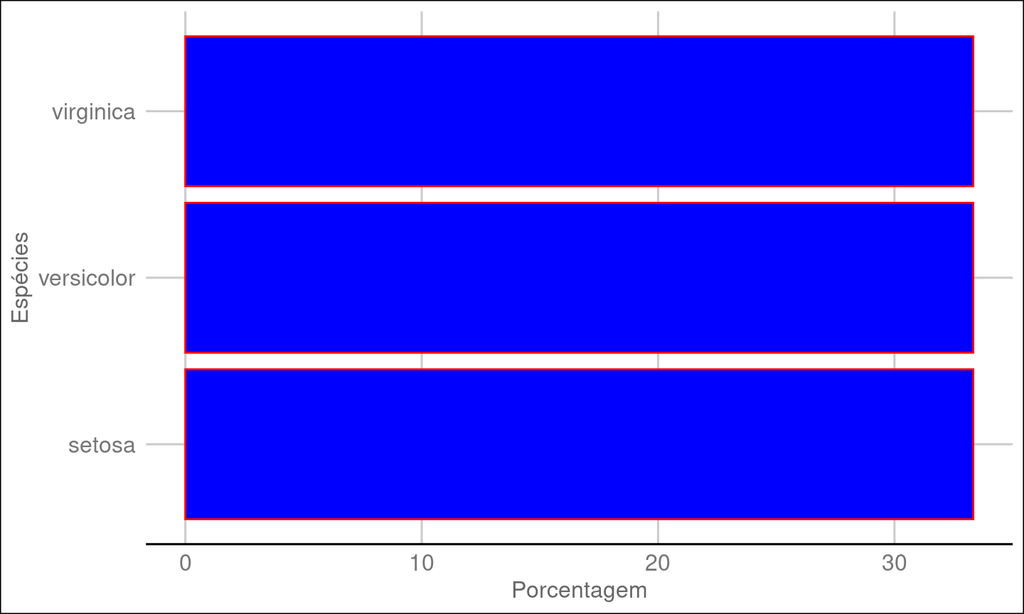

```r
ggplot(dados_iris) +
  geom_bar(mapping = aes(x = Species, y = ..prop.. * 100, group = 1),
  fill = "blue", color = "red") +
  labs(x = "Espécies", y = "Porcentagem") +
  theme_gdocs() +
  coord_flip()
```

## Tabela de Distribuição de Frequências

#### Tabela de Distribuição de Frequências

- `X`: variável quantitativa contínua

Tabela de Distribuição de Frequências para a variável quantitativa contínua.

| `X` | Frequência | Frequência relativa | Porcentagem |
| --- | --- | --- | --- |
| \([l_0, l_1)\) | \(n_1\) | \(f_1 = \frac{n_1}{n_1 + \dots + n_k}\) | \(p_1 = f_1 \cdot 100\) |
| \([l_1, l_2)\) | \(n_2\) | \(f_2 = \frac{n_2}{n_1 + \dots + n_k}\) | \(p_2 = f_2 \cdot 100\) |
| \(\vdots\) | \(\vdots\) | \(\vdots\) | \(\vdots\) |
| \([l_{k-1}, l_k]\) | \(n_k\) | \(f_k = \frac{n_k}{n_1 + \dots + n_k}\) | \(p_k = f_k \cdot 100\) |

Em que \(\min = l_0 \leq l_1 \leq \cdots \leq l_{k-1} \leq l_k = \max\) (\(\min\) é o menor valor do suporte da variável `X` e \(\max\) é o maior valor do suporte da variável `X`), \(n_i\) é número de valores de `X` entre \(l_{i-1}\) e \(l_i\), e \(l_0, l_1, \dots, l_k\) quebram o suporte da variável `X` (*breakpoints*).

\(l_0, l_1, \cdots, l_k\) são escolhidos de acordo com a teoria por trás da análise de dados (ou pelo regulador). Se você está em uma nova área, use \(l_0, l_1, \cdots, l_k\) igualmente espaçados, e use a [regra de Sturges](https://onlinelibrary.wiley.com/doi/10.1002/wics.35) para determinar o valor de \(k\): \(k = 1 + \log2(n)\) onde \(n\) é tamanho da amostra. Se \(1 + \log2(n)\) não é um número inteiro, usamos \(k = \lceil 1 + \log2(n) \rceil\).

## Tabela de Distribuição de Frequências

#### Tabela de Distribuição de Frequências

```r
k <- ceiling(1 + log2(nrow(dados_iris))) # regra de Sturges

dados_iris <- dados_iris |>
  mutate(sepal_length_intervalo = cut(Sepal.Length, breaks = k, include.lowest = T, right = F))

tab <- dados_iris |>
  group_by(sepal_length_intervalo) |>
  summarise(`Frequência` = n()) |>
  mutate(`Frequência relativa` = `Frequência` / sum(`Frequência`),
        Porcentagem = `Frequência relativa` * 100)
head(tab, n = 3)
```

```
## # A tibble: 3 × 4
##   sepal_length_intervalo Frequência `Frequência relativa` Porcentagem
##   <fct>                       <int>                 <dbl>       <dbl>
## 1 [4.3,4.7)                       9                 0.06          6
## 2 [4.7,5.1)                      23                 0.153        15.3
## 3 [5.1,5.5)                      20                 0.133        13.3
```

```r
write_ods(tab, "data/processed/tabela_frequencias_sepal_length.ods")
write_xlsx(tab, "data/processed/tabela_frequencias_sepal_length.xlsx")
```

## Gráficos no `tidyverse`

#### Histograma no `ggplot2`

- **função:** `geom_histogram()`. Para densidade de frequência: `geom_bar(x = <variável no eixo x>, y = ..density..)`. É necessário fornecer ou *bins* ou *breaks*:
  - Se *bins* é fornecido como um númeo inteiro, esta função cria faixas de tamanhos iguais para calcular a densidade de frequências
  - Se *breaks* é fornecido como um vetor
- Argumentos adicionais:
  - **`fill`**: mudar a cor do preenchimento das figuras geométricas
  - **`color`**: mudar a cor da figura geométrica

#### Rótulos dos eixos

- **Mudar os rótulos:** `labs(x = <rótulo do eixo x>, y = <rótulo do eixo y>)`
- **Trocar o eixo-x pelo eixo-y:** `coord_flip()`

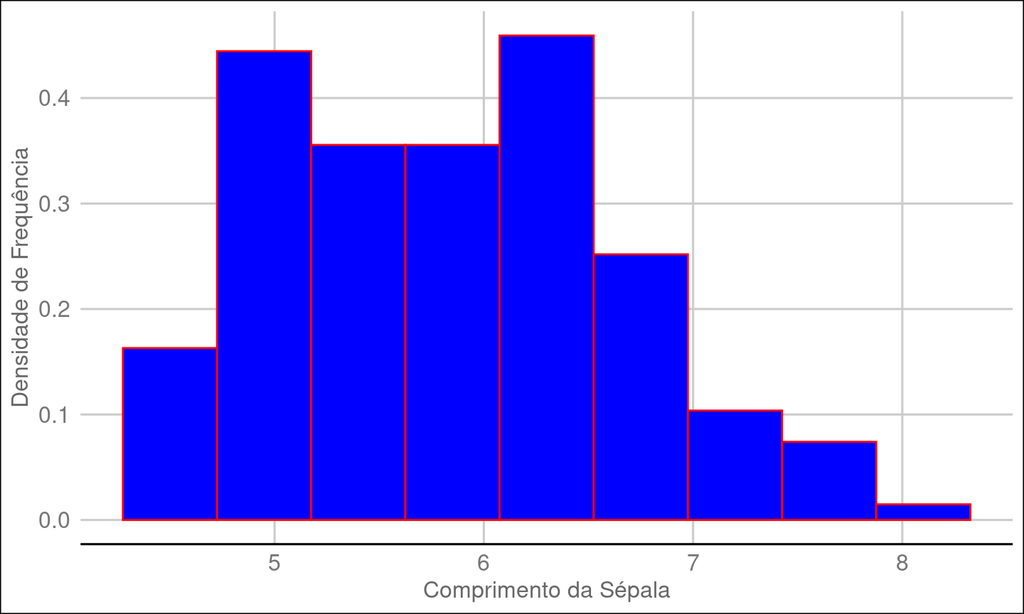

```r
k <- ceiling(1 + log2(nrow(dados_iris))) # regra de Sturges

dados_iris <- dados_iris |>
  mutate(sepal_length_intervalo = cut(Sepal.Length, breaks = k, include.lowest = T,
                                      right = F))

ggplot(dados_iris) +
  geom_histogram(aes(x = Sepal.Length, y = ..density..),
                bins = k, closed = 'left', fill = "blue", color = "red") +
  theme_gdocs() +
  labs(x = "Comprimento da Sépala", y = "Densidade de Frequência")
```

## Gráficos no `tidyverse`

#### Diagrama de caixa (boxplot) no `ggplot2`

- **função:** `geom_boxplot()`. É necessário fornecer a variável *y*:
- Argumentos adicionais:
  - **`fill`**: mudar a cor do preenchimento das figuras geométricas
  - **`color`**: mudar a cor da figura geométrica

#### Rótulos dos eixos

- **Mudar os rótulos:** `labs(x = <rótulo do eixo x>, y = <rótulo do eixo y>)`
- **Trocar o eixo-x pelo eixo-y:** `coord_flip()`

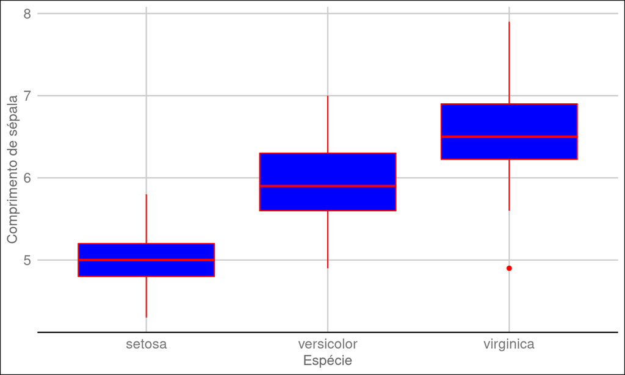

```r
ggplot(dados_iris) +
  geom_boxplot(aes(x = Species, y = Sepal.Length), fill = "blue", color = "red") +
  labs(x = "Espécie", y = "Comprimento de sépala") +
  theme_gdocs()
```

## Medidas de resumo

- Usamos a função `summarise` do pacote `dplyr`
- Usamos a função `group_by` do pacote `dplyr` (medidas de resumo por categoria)

```r
tab <- dados_iris |>
  group_by(Species) |>
  summarise(`Média` = mean(Sepal.Length), `Variância` = var(Sepal.Length),
            `Desvio Padrão` = sd(Sepal.Length), Mediana = median(Sepal.Length),
            q1 = quantile(Sepal.Length, probs = 0.25),
            q3 = quantile(Sepal.Length, probs = 0.75))

tab
```

```
## # A tibble: 3 × 7
##   Species    Média Variância `Desvio Padrão` Mediana    q1    q3
##   <chr>      <dbl>     <dbl>           <dbl>   <dbl> <dbl> <dbl>
## 1 setosa      5.01     0.124           0.352     5    4.8    5.2
## 2 versicolor  5.94     0.266           0.516     5.9  5.6    6.3
## 3 virginica   6.59     0.404           0.636     6.5  6.22   6.9
```

```r
write_ods(tab, 'data/processed/medidas_resumo_sepal_length.ods')
write_xlsx(tab, 'data/processed/medidas_resumo_sepal_length.xlsx')
```

## Tabela de contingência

- `empresa.xlsx`: conjunto de dados com informações socio-econômicas de `36` funcionários de uma determinada empresa. Este conjunto de dados é um exemplo didátivo do livro [`Estatística Bussab` de Bussab e Morettin](https://www.saraiva.com.br/estatistica-basica-9-ed-2017-9748081/p). Este conjunto de dados pode ser baixado na página pessoal de Pedro Morettin: [Pedro Morettin](http://www.ime.usp.br/~pam/dados.RData).

```r
dados_funcionarios <- read_xlsx("data/raw/empresa.xlsx")

tab <- dados_funcionarios |>
  group_by(`Estado Civil`, `Grau de Escolaridade`) |>
  summarise(`Frequência` = n(), .groups = 'rowwise') |>
  pivot_wider(names_from = `Grau de Escolaridade`, values_from = `Frequência`)
tab
```

```
## # A tibble: 2 × 4
##   `Estado Civil` `ensino fundamental` `ensino médio` superior
##   <chr>                         <int>          <int>    <int>
## 1 casado                            5             12        3
## 2 solteiro                          7              6        3
```

```r
write_ods(tab, "data/processed/contingencia_estado_civil_escolaridade.ods")
write_xlsx(tab, "data/processed/contingencia_estado_civil_escolaridade.xlsx")
```

## Gráfico de barras (duas variáveis)

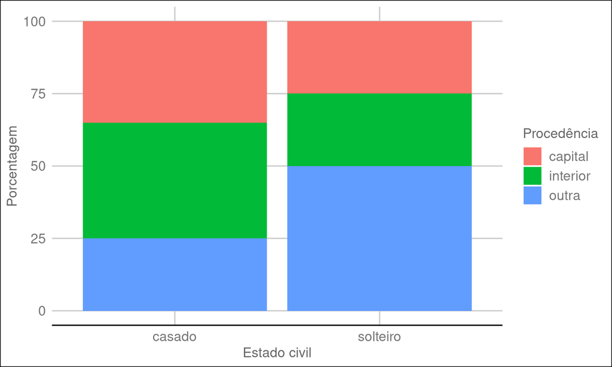

```r
ggplot(dados_funcionarios) +
  geom_bar(aes(x = `Estado Civil`, fill = Procedencia), position = 'fill') +
  labs(x = "Estado civil", y = "Porcentagem", fill = "Procedência") +
  scale_y_continuous(breaks = c(0, 0.25, 0.5, 0.75, 1),
                    labels = c(0, 25, 50, 75, 100)) +
  theme_gdocs()
```

## Gráfico de dispersão (duas variáveis)

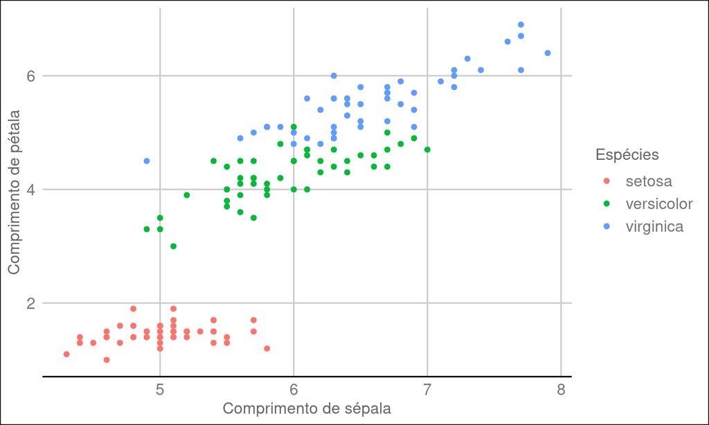

```r
ggplot(dados_iris) +
  geom_point(aes(x = Sepal.Length, y = Petal.Length, color = Species)) +
  labs(x = "Comprimento de sépala", y = "Comprimento de pétala",
      color = "Espécies") +
  theme_gdocs()
```

## Gráfico *violin*

- Generalização do diagrama de caixa. Para mais detalhes, consulte: [`geom_violin`](https://ggplot2.tidyverse.org/reference/geom_violin.html)

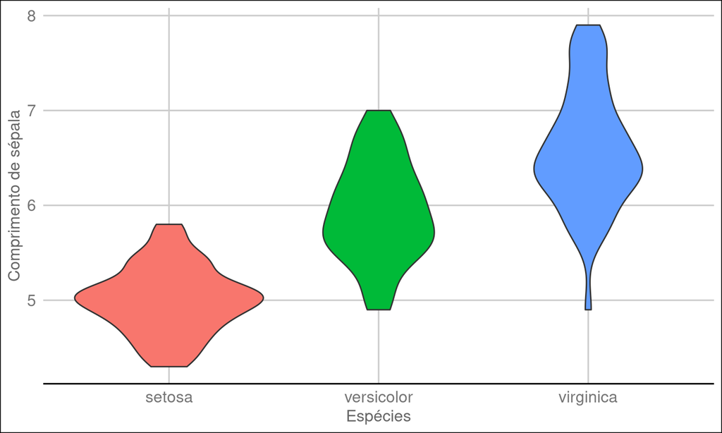

```r
ggplot(dados_iris) +
  geom_violin(aes(x = Species, y = Sepal.Length, fill = Species),
              show.legend = FALSE) +
  labs(x = "Espécies", y = "Comprimento de sépala") +
  theme_gdocs()
```

## Gráfico *lvplot*

- Generalização do diagrama de caixa. Para mais detalhes, consulte: [`lvplot`](https://doi.org/10.1080/10618600.2017.1305277)
- **Pacote:** `lvplot`

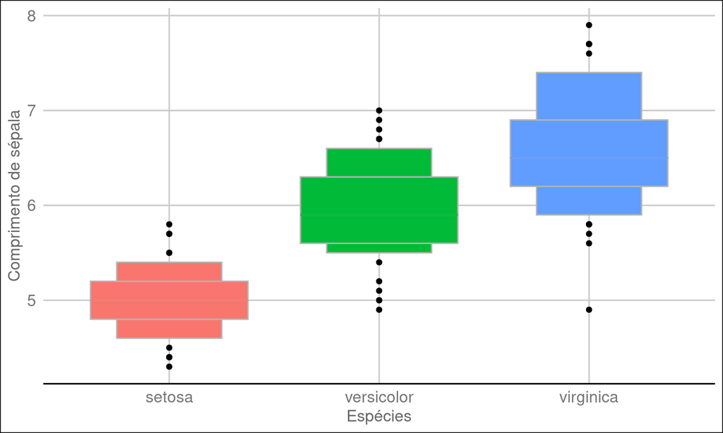

```r
ggplot(dados_iris) +
  geom_lv(aes(x = Species, y = Sepal.Length, fill = Species),
              show.legend = FALSE) +
  labs(x = "Espécies", y = "Comprimento de sépala") +
  theme_gdocs()
```